# Risk Factor Analysis

## Outcome Variable

**Outcome Variable:** stunted

## Predictor Variables

**Intervention Variable:** hfoodsec

**Adjustment Set:**

unadjusted

## Stratifying Variables

The analysis was stratified on these variable(s):

- agecat
- studyid

The following strata were considered:

- agecat: 12 months, studyid: ki0047075b-MAL-ED
- agecat: 12 months, studyid: ki1017093-NIH-Birth
- agecat: 12 months, studyid: ki1017093c-NIH-Crypto
- agecat: 12 months, studyid: ki1113344-GMS-Nepal
- agecat: 18 months, studyid: ki0047075b-MAL-ED
- agecat: 18 months, studyid: ki1017093-NIH-Birth
- agecat: 18 months, studyid: ki1017093c-NIH-Crypto
- agecat: 18 months, studyid: ki1113344-GMS-Nepal
- agecat: 24 months, studyid: ki0047075b-MAL-ED
- agecat: 24 months, studyid: ki1017093-NIH-Birth
- agecat: 24 months, studyid: ki1017093c-NIH-Crypto
- agecat: 24 months, studyid: ki1113344-GMS-Nepal
- agecat: 3 months, studyid: ki0047075b-MAL-ED
- agecat: 3 months, studyid: ki1017093-NIH-Birth
- agecat: 3 months, studyid: ki1017093c-NIH-Crypto
- agecat: 3 months, studyid: ki1113344-GMS-Nepal
- agecat: 6 months, studyid: ki0047075b-MAL-ED
- agecat: 6 months, studyid: ki1017093-NIH-Birth
- agecat: 6 months, studyid: ki1017093c-NIH-Crypto
- agecat: 6 months, studyid: ki1113344-GMS-Nepal
- agecat: 9 months, studyid: ki0047075b-MAL-ED
- agecat: 9 months, studyid: ki1017093-NIH-Birth
- agecat: 9 months, studyid: ki1017093c-NIH-Crypto
- agecat: 9 months, studyid: ki1113344-GMS-Nepal
- agecat: Birth, studyid: ki0047075b-MAL-ED
- agecat: Birth, studyid: ki1017093-NIH-Birth
- agecat: Birth, studyid: ki1017093c-NIH-Crypto

### Dropped Strata

Some strata were dropped due to rare outcomes:

- agecat: Birth, studyid: ki1017093-NIH-Birth
- agecat: Birth, studyid: ki1017093c-NIH-Crypto
- agecat: 3 months, studyid: ki1017093-NIH-Birth
- agecat: 3 months, studyid: ki1113344-GMS-Nepal
- agecat: 6 months, studyid: ki1017093-NIH-Birth
- agecat: 6 months, studyid: ki1113344-GMS-Nepal
- agecat: 9 months, studyid: ki1017093-NIH-Birth
- agecat: 12 months, studyid: ki1017093-NIH-Birth
- agecat: 18 months, studyid: ki1017093-NIH-Birth
- agecat: 24 months, studyid: ki1017093-NIH-Birth

## Methods Detail

We’re interested in the causal parameters $E[Y_a]$ for all values of $a \in \mathcal{A}$. These parameters represent the mean outcome if, possibly contrary to fact, we intervened to set all units to have $A=a$. Under the randomization and positivity assumptions, these are identified by the statistical parameters $\psi_a=E_W[E_{Y|A,W}(Y|A=a,W)]$. In addition, we’re interested in the mean of $Y$, $E[Y]$ under no intervention (the observed mean). We will estimate these parameters by using SuperLearner to fit the relevant likelihood factors – $E_{Y|A,W}(Y|A=a,W)$ and $p(A=a|W)$, and then updating our likelihood fit using a joint TMLE.

For unadjusted analyses ($W=\{\}$), initial likelihoods were estimated using Lrnr_glm to estimate the simple $E(Y|A)$ and Lrnr_mean to estimate $p(A)$. For adjusted analyses, a small library containing Lrnr_glmnet, Lrnr_xgboost, and Lrnr_mean was used.

Having estimated these parameters, we will then use the delta method to estimate relative risks and attributable risks relative to a prespecified baseline level of $A$.

# Results Detail

## Results Plots

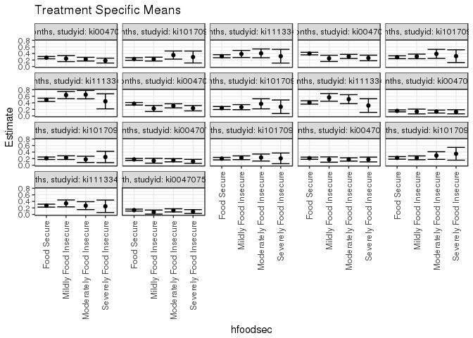

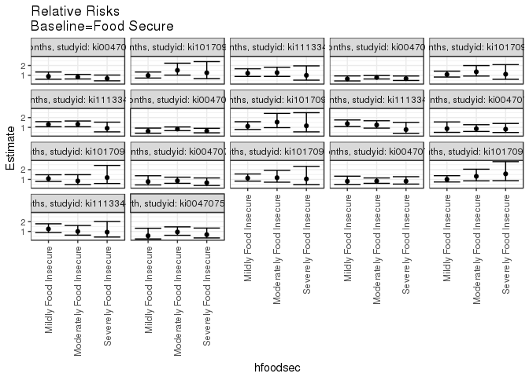

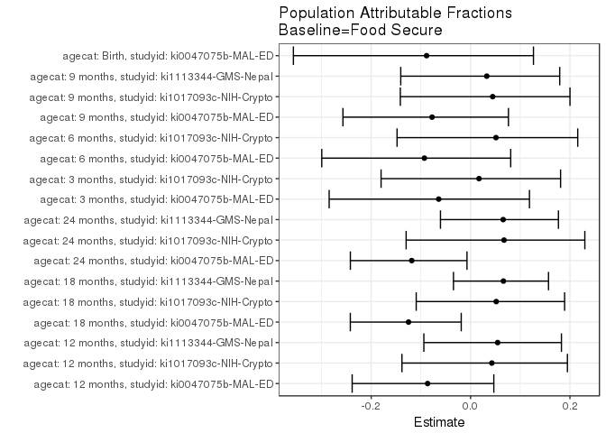

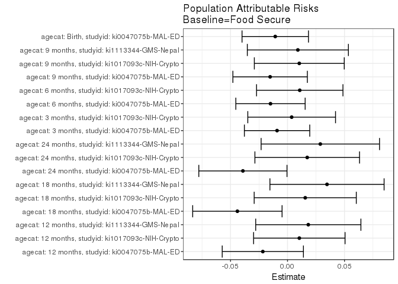

## Data Summary

| agecat | studyid | A | n | nA | nAY0 | nAY1 |
| --- | --- | --- | --- | --- | --- | --- |
| Birth | ki0047075b-MAL-ED | Food Secure | 863 | 521 | 452 | 69 |
| Birth | ki0047075b-MAL-ED | Mildly Food Insecure | 863 | 68 | 63 | 5 |
| Birth | ki0047075b-MAL-ED | Moderately Food Insecure | 863 | 184 | 161 | 23 |
| Birth | ki0047075b-MAL-ED | Severely Food Insecure | 863 | 90 | 82 | 8 |
| Birth | ki1017093-NIH-Birth | Food Secure | 28 | 3 | 3 | 0 |
| Birth | ki1017093-NIH-Birth | Mildly Food Insecure | 28 | 21 | 21 | 0 |
| Birth | ki1017093-NIH-Birth | Moderately Food Insecure | 28 | 4 | 3 | 1 |
| Birth | ki1017093-NIH-Birth | Severely Food Insecure | 28 | 0 | 0 | 0 |
| Birth | ki1017093c-NIH-Crypto | Food Secure | 27 | 14 | 14 | 0 |
| Birth | ki1017093c-NIH-Crypto | Mildly Food Insecure | 27 | 9 | 5 | 4 |
| Birth | ki1017093c-NIH-Crypto | Moderately Food Insecure | 27 | 2 | 2 | 0 |
| Birth | ki1017093c-NIH-Crypto | Severely Food Insecure | 27 | 2 | 1 | 1 |
| Birth | ki1113344-GMS-Nepal | Food Secure | 0 | 0 | 0 | 0 |
| Birth | ki1113344-GMS-Nepal | Mildly Food Insecure | 0 | 0 | 0 | 0 |
| Birth | ki1113344-GMS-Nepal | Moderately Food Insecure | 0 | 0 | 0 | 0 |
| Birth | ki1113344-GMS-Nepal | Severely Food Insecure | 0 | 0 | 0 | 0 |
| 3 months | ki0047075b-MAL-ED | Food Secure | 1006 | 604 | 512 | 92 |
| 3 months | ki0047075b-MAL-ED | Mildly Food Insecure | 1006 | 83 | 72 | 11 |
| 3 months | ki0047075b-MAL-ED | Moderately Food Insecure | 1006 | 214 | 186 | 28 |
| 3 months | ki0047075b-MAL-ED | Severely Food Insecure | 1006 | 105 | 92 | 13 |
| 3 months | ki1017093-NIH-Birth | Food Secure | 570 | 84 | 70 | 14 |
| 3 months | ki1017093-NIH-Birth | Mildly Food Insecure | 570 | 446 | 343 | 103 |
| 3 months | ki1017093-NIH-Birth | Moderately Food Insecure | 570 | 35 | 24 | 11 |
| 3 months | ki1017093-NIH-Birth | Severely Food Insecure | 570 | 5 | 3 | 2 |
| 3 months | ki1017093c-NIH-Crypto | Food Secure | 728 | 432 | 341 | 91 |
| 3 months | ki1017093c-NIH-Crypto | Mildly Food Insecure | 728 | 210 | 162 | 48 |
| 3 months | ki1017093c-NIH-Crypto | Moderately Food Insecure | 728 | 62 | 51 | 11 |
| 3 months | ki1017093c-NIH-Crypto | Severely Food Insecure | 728 | 24 | 18 | 6 |
| 3 months | ki1113344-GMS-Nepal | Food Secure | 553 | 399 | 345 | 54 |
| 3 months | ki1113344-GMS-Nepal | Mildly Food Insecure | 553 | 79 | 63 | 16 |

[output cut: 82 more lines]

## Results Table

### Parameter: TSM

| agecat | studyid | intervention_level | baseline_level | estimate | ci_lower | ci_upper |
| --- | --- | --- | --- | --- | --- | --- |
| Birth | ki0047075b-MAL-ED | Food Secure | NA | 0.1324376 | 0.1033146 | 0.1615607 |
| Birth | ki0047075b-MAL-ED | Mildly Food Insecure | NA | 0.0735294 | 0.0114580 | 0.1356008 |
| Birth | ki0047075b-MAL-ED | Moderately Food Insecure | NA | 0.1250000 | 0.0771866 | 0.1728134 |
| Birth | ki0047075b-MAL-ED | Severely Food Insecure | NA | 0.0888889 | 0.0300604 | 0.1477174 |
| 3 months | ki0047075b-MAL-ED | Food Secure | NA | 0.1523179 | 0.1236472 | 0.1809885 |
| 3 months | ki0047075b-MAL-ED | Mildly Food Insecure | NA | 0.1325301 | 0.0595492 | 0.2055111 |
| 3 months | ki0047075b-MAL-ED | Moderately Food Insecure | NA | 0.1308411 | 0.0856369 | 0.1760453 |
| 3 months | ki0047075b-MAL-ED | Severely Food Insecure | NA | 0.1238095 | 0.0607798 | 0.1868393 |
| 3 months | ki1017093c-NIH-Crypto | Food Secure | NA | 0.2106481 | 0.1721696 | 0.2491267 |
| 3 months | ki1017093c-NIH-Crypto | Mildly Food Insecure | NA | 0.2285714 | 0.1717391 | 0.2854038 |
| 3 months | ki1017093c-NIH-Crypto | Moderately Food Insecure | NA | 0.1774194 | 0.0822624 | 0.2725763 |
| 3 months | ki1017093c-NIH-Crypto | Severely Food Insecure | NA | 0.2500000 | 0.0766429 | 0.4233571 |
| 6 months | ki0047075b-MAL-ED | Food Secure | NA | 0.1757877 | 0.1453915 | 0.2061840 |
| 6 months | ki0047075b-MAL-ED | Mildly Food Insecure | NA | 0.1358025 | 0.0611605 | 0.2104444 |
| 6 months | ki0047075b-MAL-ED | Moderately Food Insecure | NA | 0.1502347 | 0.1022271 | 0.1982423 |
| 6 months | ki0047075b-MAL-ED | Severely Food Insecure | NA | 0.1153846 | 0.0539519 | 0.1768173 |
| 6 months | ki1017093c-NIH-Crypto | Food Secure | NA | 0.1990632 | 0.1611638 | 0.2369627 |
| 6 months | ki1017093c-NIH-Crypto | Mildly Food Insecure | NA | 0.2254902 | 0.1681031 | 0.2828773 |
| 6 months | ki1017093c-NIH-Crypto | Moderately Food Insecure | NA | 0.2333333 | 0.1262386 | 0.3404281 |
| 6 months | ki1017093c-NIH-Crypto | Severely Food Insecure | NA | 0.2083333 | 0.0457422 | 0.3709245 |
| 9 months | ki0047075b-MAL-ED | Food Secure | NA | 0.2122720 | 0.1796176 | 0.2449263 |
| 9 months | ki0047075b-MAL-ED | Mildly Food Insecure | NA | 0.1707317 | 0.0892495 | 0.2522140 |
| 9 months | ki0047075b-MAL-ED | Moderately Food Insecure | NA | 0.1753555 | 0.1240200 | 0.2266909 |
| 9 months | ki0047075b-MAL-ED | Severely Food Insecure | NA | 0.1730769 | 0.1003323 | 0.2458215 |
| 9 months | ki1017093c-NIH-Crypto | Food Secure | NA | 0.2219626 | 0.1825646 | 0.2613606 |
| 9 months | ki1017093c-NIH-Crypto | Mildly Food Insecure | NA | 0.2233503 | 0.1651495 | 0.2815510 |
| 9 months | ki1017093c-NIH-Crypto | Moderately Food Insecure | NA | 0.2931034 | 0.1758757 | 0.4103312 |
| 9 months | ki1017093c-NIH-Crypto | Severely Food Insecure | NA | 0.3478261 | 0.1530414 | 0.5426107 |
| 9 months | ki1113344-GMS-Nepal | Food Secure | NA | 0.2694301 | 0.2251289 | 0.3137312 |
| 9 months | ki1113344-GMS-Nepal | Mildly Food Insecure | NA | 0.3376623 | 0.2319343 | 0.4433903 |
| 9 months | ki1113344-GMS-Nepal | Moderately Food Insecure | NA | 0.2692308 | 0.1485591 | 0.3899024 |
| 9 months | ki1113344-GMS-Nepal | Severely Food Insecure | NA | 0.2500000 | 0.0600497 | 0.4399503 |
| 12 months | ki0047075b-MAL-ED | Food Secure | NA | 0.2724252 | 0.2368433 | 0.3080072 |
| 12 months | ki0047075b-MAL-ED | Mildly Food Insecure | NA | 0.2439024 | 0.1509084 | 0.3368965 |
| 12 months | ki0047075b-MAL-ED | Moderately Food Insecure | NA | 0.2253521 | 0.1692139 | 0.2814903 |
| 12 months | ki0047075b-MAL-ED | Severely Food Insecure | NA | 0.1826923 | 0.1083902 | 0.2569945 |
| 12 months | ki1017093c-NIH-Crypto | Food Secure | NA | 0.2318501 | 0.1917940 | 0.2719062 |
| 12 months | ki1017093c-NIH-Crypto | Mildly Food Insecure | NA | 0.2272727 | 0.1688597 | 0.2856858 |
| 12 months | ki1017093c-NIH-Crypto | Moderately Food Insecure | NA | 0.3508772 | 0.2268950 | 0.4748594 |
| 12 months | ki1017093c-NIH-Crypto | Severely Food Insecure | NA | 0.2916667 | 0.1096913 | 0.4736420 |
| 12 months | ki1113344-GMS-Nepal | Food Secure | NA | 0.3163265 | 0.2702480 | 0.3624051 |
| 12 months | ki1113344-GMS-Nepal | Mildly Food Insecure | NA | 0.3846154 | 0.2765494 | 0.4926814 |
| 12 months | ki1113344-GMS-Nepal | Moderately Food Insecure | NA | 0.4038462 | 0.2703603 | 0.5373320 |
| 12 months | ki1113344-GMS-Nepal | Severely Food Insecure | NA | 0.3157895 | 0.1065870 | 0.5249919 |
| 18 months | ki0047075b-MAL-ED | Food Secure | NA | 0.3963516 | 0.3572909 | 0.4354122 |
| 18 months | ki0047075b-MAL-ED | Mildly Food Insecure | NA | 0.2500000 | 0.1550661 | 0.3449339 |
| 18 months | ki0047075b-MAL-ED | Moderately Food Insecure | NA | 0.3098592 | 0.2477255 | 0.3719928 |
| 18 months | ki0047075b-MAL-ED | Severely Food Insecure | NA | 0.2621359 | 0.1771595 | 0.3471123 |
| 18 months | ki1017093c-NIH-Crypto | Food Secure | NA | 0.2857143 | 0.2409584 | 0.3304701 |
| 18 months | ki1017093c-NIH-Crypto | Mildly Food Insecure | NA | 0.3099415 | 0.2405709 | 0.3793122 |
| 18 months | ki1017093c-NIH-Crypto | Moderately Food Insecure | NA | 0.3877551 | 0.2512232 | 0.5242870 |
| 18 months | ki1017093c-NIH-Crypto | Severely Food Insecure | NA | 0.3181818 | 0.1233986 | 0.5129650 |
| 18 months | ki1113344-GMS-Nepal | Food Secure | NA | 0.4896907 | 0.4399036 | 0.5394778 |
| 18 months | ki1113344-GMS-Nepal | Mildly Food Insecure | NA | 0.6351351 | 0.5253513 | 0.7449190 |
| 18 months | ki1113344-GMS-Nepal | Moderately Food Insecure | NA | 0.6481481 | 0.5206584 | 0.7756379 |
| 18 months | ki1113344-GMS-Nepal | Severely Food Insecure | NA | 0.4444444 | 0.2146755 | 0.6742134 |
| 24 months | ki0047075b-MAL-ED | Food Secure | NA | 0.3698176 | 0.3312667 | 0.4083684 |
| 24 months | ki0047075b-MAL-ED | Mildly Food Insecure | NA | 0.2250000 | 0.1334490 | 0.3165510 |
| 24 months | ki0047075b-MAL-ED | Moderately Food Insecure | NA | 0.3066038 | 0.2445058 | 0.3687017 |
| 24 months | ki0047075b-MAL-ED | Severely Food Insecure | NA | 0.2330097 | 0.1513272 | 0.3146922 |
| 24 months | ki1017093c-NIH-Crypto | Food Secure | NA | 0.2395210 | 0.1937054 | 0.2853365 |
| 24 months | ki1017093c-NIH-Crypto | Mildly Food Insecure | NA | 0.2661290 | 0.1882687 | 0.3439893 |
| 24 months | ki1017093c-NIH-Crypto | Moderately Food Insecure | NA | 0.3684211 | 0.2149010 | 0.5219411 |
| 24 months | ki1017093c-NIH-Crypto | Severely Food Insecure | NA | 0.2777778 | 0.0706593 | 0.4848963 |
| 24 months | ki1113344-GMS-Nepal | Food Secure | NA | 0.4097421 | 0.3580937 | 0.4613905 |
| 24 months | ki1113344-GMS-Nepal | Mildly Food Insecure | NA | 0.5652174 | 0.4481293 | 0.6823055 |
| 24 months | ki1113344-GMS-Nepal | Moderately Food Insecure | NA | 0.5098039 | 0.3724646 | 0.6471433 |
| 24 months | ki1113344-GMS-Nepal | Severely Food Insecure | NA | 0.3157895 | 0.1065660 | 0.5250130 |

### Parameter: E(Y)

| agecat | studyid | intervention_level | baseline_level | estimate | ci_lower | ci_upper |
| --- | --- | --- | --- | --- | --- | --- |
| Birth | ki0047075b-MAL-ED | NA | NA | 0.1216686 | 0.1203897 | 0.1229475 |
| 3 months | ki0047075b-MAL-ED | NA | NA | 0.1431412 | 0.1424334 | 0.1438489 |
| 3 months | ki1017093c-NIH-Crypto | NA | NA | 0.2142857 | 0.2131965 | 0.2153749 |
| 6 months | ki0047075b-MAL-ED | NA | NA | 0.1608392 | 0.1595630 | 0.1621153 |
| 6 months | ki1017093c-NIH-Crypto | NA | NA | 0.2097902 | 0.2087908 | 0.2107896 |
| 9 months | ki0047075b-MAL-ED | NA | NA | 0.1970000 | 0.1958307 | 0.1981693 |
| 9 months | ki1017093c-NIH-Crypto | NA | NA | 0.2322946 | 0.2301736 | 0.2344157 |
| 9 months | ki1113344-GMS-Nepal | NA | NA | 0.2785047 | 0.2764239 | 0.2805854 |
| 12 months | ki0047075b-MAL-ED | NA | NA | 0.2507493 | 0.2488848 | 0.2526137 |
| 12 months | ki1017093c-NIH-Crypto | NA | NA | 0.2422096 | 0.2396912 | 0.2447281 |
| 12 months | ki1113344-GMS-Nepal | NA | NA | 0.3345656 | 0.3317990 | 0.3373322 |
| 18 months | ki0047075b-MAL-ED | NA | NA | 0.3523524 | 0.3488255 | 0.3558792 |
| 18 months | ki1017093c-NIH-Crypto | NA | NA | 0.3012618 | 0.2991172 | 0.3034065 |
| 18 months | ki1113344-GMS-Nepal | NA | NA | 0.5243446 | 0.5187526 | 0.5299365 |
| 24 months | ki0047075b-MAL-ED | NA | NA | 0.3306613 | 0.3273023 | 0.3340204 |
| 24 months | ki1017093c-NIH-Crypto | NA | NA | 0.2568093 | 0.2538729 | 0.2597458 |
| 24 months | ki1113344-GMS-Nepal | NA | NA | 0.4385246 | 0.4329219 | 0.4441273 |

### Parameter: RR

| agecat | studyid | intervention_level | baseline_level | estimate | ci_lower | ci_upper |
| --- | --- | --- | --- | --- | --- | --- |
| Birth | ki0047075b-MAL-ED | Mildly Food Insecure | Food Secure | 0.5552003 | 0.2320578 | 1.3283218 |
| Birth | ki0047075b-MAL-ED | Moderately Food Insecure | Food Secure | 0.9438406 | 0.6071314 | 1.4672855 |
| Birth | ki0047075b-MAL-ED | Severely Food Insecure | Food Secure | 0.6711755 | 0.3341645 | 1.3480685 |
| 3 months | ki0047075b-MAL-ED | Mildly Food Insecure | Food Secure | 0.8700891 | 0.4862096 | 1.5570547 |
| 3 months | ki0047075b-MAL-ED | Moderately Food Insecure | Food Secure | 0.8590004 | 0.5795964 | 1.2730958 |
| 3 months | ki0047075b-MAL-ED | Severely Food Insecure | Food Secure | 0.8128364 | 0.4723687 | 1.3987020 |
| 3 months | ki1017093c-NIH-Crypto | Mildly Food Insecure | Food Secure | 1.0850863 | 0.7970250 | 1.4772591 |
| 3 months | ki1017093c-NIH-Crypto | Moderately Food Insecure | Food Secure | 0.8422545 | 0.4779422 | 1.4842646 |
| 3 months | ki1017093c-NIH-Crypto | Severely Food Insecure | Food Secure | 1.1868132 | 0.5793707 | 2.4311302 |
| 6 months | ki0047075b-MAL-ED | Mildly Food Insecure | Food Secure | 0.7725367 | 0.4341915 | 1.3745386 |
| 6 months | ki0047075b-MAL-ED | Moderately Food Insecure | Food Secure | 0.8546373 | 0.5942752 | 1.2290684 |
| 6 months | ki0047075b-MAL-ED | Severely Food Insecure | Food Secure | 0.6563861 | 0.3750117 | 1.1488781 |
| 6 months | ki1017093c-NIH-Crypto | Mildly Food Insecure | Food Secure | 1.1327566 | 0.8243345 | 1.5565739 |
| 6 months | ki1017093c-NIH-Crypto | Moderately Food Insecure | Food Secure | 1.1721569 | 0.7131575 | 1.9265755 |
| 6 months | ki1017093c-NIH-Crypto | Severely Food Insecure | Food Secure | 1.0465686 | 0.4686927 | 2.3369383 |
| 9 months | ki0047075b-MAL-ED | Mildly Food Insecure | Food Secure | 0.8043064 | 0.4871379 | 1.3279788 |
| 9 months | ki0047075b-MAL-ED | Moderately Food Insecure | Food Secure | 0.8260886 | 0.5934747 | 1.1498761 |
| 9 months | ki0047075b-MAL-ED | Severely Food Insecure | Food Secure | 0.8153546 | 0.5211582 | 1.2756263 |
| 9 months | ki1017093c-NIH-Crypto | Mildly Food Insecure | Food Secure | 1.0062517 | 0.7341382 | 1.3792260 |
| 9 months | ki1017093c-NIH-Crypto | Moderately Food Insecure | Food Secure | 1.3205082 | 0.8525236 | 2.0453882 |
| 9 months | ki1017093c-NIH-Crypto | Severely Food Insecure | Food Secure | 1.5670481 | 0.8708645 | 2.8197725 |
| 9 months | ki1113344-GMS-Nepal | Mildly Food Insecure | Food Secure | 1.2532468 | 0.8799181 | 1.7849701 |
| 9 months | ki1113344-GMS-Nepal | Moderately Food Insecure | Food Secure | 0.9992604 | 0.6199250 | 1.6107130 |
| 9 months | ki1113344-GMS-Nepal | Severely Food Insecure | Food Secure | 0.9278846 | 0.4264599 | 2.0188762 |
| 12 months | ki0047075b-MAL-ED | Mildly Food Insecure | Food Secure | 0.8953004 | 0.5983241 | 1.3396799 |
| 12 months | ki0047075b-MAL-ED | Moderately Food Insecure | Food Secure | 0.8272071 | 0.6243918 | 1.0959011 |
| 12 months | ki0047075b-MAL-ED | Severely Food Insecure | Food Secure | 0.6706144 | 0.4374795 | 1.0279882 |
| 12 months | ki1017093c-NIH-Crypto | Mildly Food Insecure | Food Secure | 0.9802571 | 0.7191911 | 1.3360899 |
| 12 months | ki1017093c-NIH-Crypto | Moderately Food Insecure | Food Secure | 1.5133794 | 1.0212430 | 2.2426760 |
| 12 months | ki1017093c-NIH-Crypto | Severely Food Insecure | Food Secure | 1.2579966 | 0.6584455 | 2.4034722 |
| 12 months | ki1113344-GMS-Nepal | Mildly Food Insecure | Food Secure | 1.2158809 | 0.8860177 | 1.6685518 |
| 12 months | ki1113344-GMS-Nepal | Moderately Food Insecure | Food Secure | 1.2766749 | 0.8896278 | 1.8321132 |
| 12 months | ki1113344-GMS-Nepal | Severely Food Insecure | Food Secure | 0.9983022 | 0.5066172 | 1.9671802 |
| 18 months | ki0047075b-MAL-ED | Mildly Food Insecure | Food Secure | 0.6307531 | 0.4260682 | 0.9337697 |
| 18 months | ki0047075b-MAL-ED | Moderately Food Insecure | Food Secure | 0.7817785 | 0.6252432 | 0.9775040 |
| 18 months | ki0047075b-MAL-ED | Severely Food Insecure | Food Secure | 0.6613722 | 0.4713017 | 0.9280960 |
| 18 months | ki1017093c-NIH-Crypto | Mildly Food Insecure | Food Secure | 1.0847953 | 0.8254735 | 1.4255830 |
| 18 months | ki1017093c-NIH-Crypto | Moderately Food Insecure | Food Secure | 1.3571429 | 0.9231172 | 1.9952360 |
| 18 months | ki1017093c-NIH-Crypto | Severely Food Insecure | Food Secure | 1.1136364 | 0.5919880 | 2.0949510 |
| 18 months | ki1113344-GMS-Nepal | Mildly Food Insecure | Food Secure | 1.2970128 | 1.0613360 | 1.5850232 |
| 18 months | ki1113344-GMS-Nepal | Moderately Food Insecure | Food Secure | 1.3235867 | 1.0606951 | 1.6516357 |
| 18 months | ki1113344-GMS-Nepal | Severely Food Insecure | Food Secure | 0.9076023 | 0.5358872 | 1.5371557 |
| 24 months | ki0047075b-MAL-ED | Mildly Food Insecure | Food Secure | 0.6084081 | 0.3997390 | 0.9260052 |
| 24 months | ki0047075b-MAL-ED | Moderately Food Insecure | Food Secure | 0.8290676 | 0.6601814 | 1.0411580 |
| 24 months | ki0047075b-MAL-ED | Severely Food Insecure | Food Secure | 0.6300666 | 0.4370731 | 0.9082781 |
| 24 months | ki1017093c-NIH-Crypto | Mildly Food Insecure | Food Secure | 1.1110887 | 0.7833260 | 1.5759954 |
| 24 months | ki1017093c-NIH-Crypto | Moderately Food Insecure | Food Secure | 1.5381579 | 0.9724689 | 2.4329105 |
| 24 months | ki1017093c-NIH-Crypto | Severely Food Insecure | Food Secure | 1.1597222 | 0.5370896 | 2.5041549 |
| 24 months | ki1113344-GMS-Nepal | Mildly Food Insecure | Food Secure | 1.3794466 | 1.0824103 | 1.7579960 |
| 24 months | ki1113344-GMS-Nepal | Moderately Food Insecure | Food Secure | 1.2442068 | 0.9241050 | 1.6751889 |
| 24 months | ki1113344-GMS-Nepal | Severely Food Insecure | Food Secure | 0.7707030 | 0.3926340 | 1.5128164 |

### Parameter: PAR

| agecat | studyid | intervention_level | baseline_level | estimate | ci_lower | ci_upper |
| --- | --- | --- | --- | --- | --- | --- |
| Birth | ki0047075b-MAL-ED | Food Secure | NA | -0.0107690 | -0.0399202 | 0.0183821 |
| 3 months | ki0047075b-MAL-ED | Food Secure | NA | -0.0091767 | -0.0378561 | 0.0195027 |
| 3 months | ki1017093c-NIH-Crypto | Food Secure | NA | 0.0036376 | -0.0348564 | 0.0421315 |
| 6 months | ki0047075b-MAL-ED | Food Secure | NA | -0.0149486 | -0.0453716 | 0.0154745 |
| 6 months | ki1017093c-NIH-Crypto | Food Secure | NA | 0.0107270 | -0.0271856 | 0.0486396 |
| 9 months | ki0047075b-MAL-ED | Food Secure | NA | -0.0152720 | -0.0479473 | 0.0174033 |
| 9 months | ki1017093c-NIH-Crypto | Food Secure | NA | 0.0103320 | -0.0291231 | 0.0497871 |
| 9 months | ki1113344-GMS-Nepal | Food Secure | NA | 0.0090746 | -0.0352753 | 0.0534246 |
| 12 months | ki0047075b-MAL-ED | Food Secure | NA | -0.0216760 | -0.0573067 | 0.0139547 |
| 12 months | ki1017093c-NIH-Crypto | Food Secure | NA | 0.0103595 | -0.0297757 | 0.0504947 |
| 12 months | ki1113344-GMS-Nepal | Food Secure | NA | 0.0182391 | -0.0279225 | 0.0644006 |
| 18 months | ki0047075b-MAL-ED | Food Secure | NA | -0.0439992 | -0.0832188 | -0.0047797 |
| 18 months | ki1017093c-NIH-Crypto | Food Secure | NA | 0.0155475 | -0.0292597 | 0.0603547 |
| 18 months | ki1113344-GMS-Nepal | Food Secure | NA | 0.0346538 | -0.0154463 | 0.0847540 |
| 24 months | ki0047075b-MAL-ED | Food Secure | NA | -0.0391563 | -0.0778532 | -0.0004593 |
| 24 months | ki1017093c-NIH-Crypto | Food Secure | NA | 0.0172884 | -0.0286212 | 0.0631980 |
| 24 months | ki1113344-GMS-Nepal | Food Secure | NA | 0.0287825 | -0.0231689 | 0.0807339 |

### Parameter: PAF

| agecat | studyid | intervention_level | baseline_level | estimate | ci_lower | ci_upper |
| --- | --- | --- | --- | --- | --- | --- |
| Birth | ki0047075b-MAL-ED | Food Secure | NA | -0.0885111 | -0.3565736 | 0.1265815 |
| 3 months | ki0047075b-MAL-ED | Food Secure | NA | -0.0641096 | -0.2845808 | 0.1185223 |
| 3 months | ki1017093c-NIH-Crypto | Food Secure | NA | 0.0169753 | -0.1801212 | 0.1811540 |
| 6 months | ki0047075b-MAL-ED | Food Secure | NA | -0.0929411 | -0.2994861 | 0.0807749 |
| 6 months | ki1017093c-NIH-Crypto | Food Secure | NA | 0.0511319 | -0.1479331 | 0.2156767 |
| 9 months | ki0047075b-MAL-ED | Food Secure | NA | -0.0775227 | -0.2568540 | 0.0762211 |
| 9 months | ki1017093c-NIH-Crypto | Food Secure | NA | 0.0444780 | -0.1413771 | 0.2000696 |
| 9 months | ki1113344-GMS-Nepal | Food Secure | NA | 0.0325834 | -0.1405024 | 0.1794012 |
| 12 months | ki0047075b-MAL-ED | Food Secure | NA | -0.0864449 | -0.2382932 | 0.0467826 |
| 12 months | ki1017093c-NIH-Crypto | Food Secure | NA | 0.0427709 | -0.1381081 | 0.1949028 |
| 12 months | ki1113344-GMS-Nepal | Food Secure | NA | 0.0545157 | -0.0940039 | 0.1828726 |
| 18 months | ki0047075b-MAL-ED | Food Secure | NA | -0.1248728 | -0.2420055 | -0.0187868 |
| 18 months | ki1017093c-NIH-Crypto | Food Secure | NA | 0.0516081 | -0.1094004 | 0.1892492 |
| 18 months | ki1113344-GMS-Nepal | Food Secure | NA | 0.0660898 | -0.0344328 | 0.1568441 |
| 24 months | ki0047075b-MAL-ED | Food Secure | NA | -0.1184180 | -0.2419117 | -0.0072043 |
| 24 months | ki1017093c-NIH-Crypto | Food Secure | NA | 0.0673199 | -0.1296733 | 0.2299613 |
| 24 months | ki1113344-GMS-Nepal | Food Secure | NA | 0.0656348 | -0.0605726 | 0.1768236 |